```python
import numpy as np
import pandas as pd
import matplotlib.pyplot as plt
import seaborn as sns
# from statsmodels.api import OLS, add_constant
from linearmodels import PanelOLS, RandomEffects, PooledOLS
from linearmodels.panel import compare
from scipy.stats import chi2, t
```

# Загрузим данные

```python
data = pd.read_excel('data/debtOECD.xls', 'datadebt', usecols=range(1, 13))
data
```

|  | country | year | growth | ngs | pop | school | openness | infl | total_dep | bankcrisis | debtgov | realGDP |
| --- | --- | --- | --- | --- | --- | --- | --- | --- | --- | --- | --- | --- |
| 0 | 1 | 1979 | NaN | NaN | 225055.000 | NaN | NaN | NaN | NaN | NaN | NaN | NaN |
| 1 | 1 | 1980 | -1.852161 | 19.465 | 225055.000 | 11.86 | 20.751923 | 13.509370 | 50.796404 | 0.0 | 0.458956 | 25090.0 |
| 2 | 1 | 1981 | 1.452103 | 20.662 | 227726.463 | 11.86 | 20.062474 | 10.315534 | 50.382611 | 0.0 | 0.451561 | 25454.0 |
| 3 | 1 | 1982 | -2.367766 | 19.104 | 229966.237 | 11.86 | 18.158172 | 6.160616 | 50.144179 | 0.0 | 0.504318 | 24852.0 |
| 4 | 1 | 1983 | 3.973262 | 17.042 | 232187.835 | 11.86 | 17.258970 | 3.212435 | 50.057573 | 0.0 | 0.537802 | 25839.0 |
| ... | ... | ... | ... | ... | ... | ... | ... | ... | ... | ... | ... | ... |
| 553 | 18 | 2005 | 4.425367 | 24.510 | 8986.000 | 11.41 | 89.038791 | 0.453171 | 52.800035 | 0.0 | 0.655969 | 34856.0 |
| 554 | 18 | 2006 | 3.931027 | 27.153 | 9002.000 | 11.41 | 94.117615 | 1.360215 | 52.567226 | 0.0 | 0.586981 | 36227.0 |
| 555 | 18 | 2007 | 3.148673 | 29.566 | 9017.000 | 11.41 | 96.279448 | 2.212169 | 52.461504 | 0.0 | 0.529283 | 37367.0 |
| 556 | 18 | 2008 | -0.343097 | 28.904 | 9031.000 | 11.41 | 99.657369 | 3.437049 | 52.528023 | 0.0 | 0.515149 | 37239.0 |
| 557 | 18 | 2009 | -5.409407 | 23.441 | 9045.000 | 11.41 | 90.136776 | -0.278429 | 52.820595 | 0.0 | 0.578353 | 35225.0 |

558 rows × 12 columns

```python
data = data.set_index(['country', 'year'])
data
```

| country | year | growth | ngs | pop | school | openness | infl | total_dep | bankcrisis | debtgov | realGDP |
| --- | --- | --- | --- | --- | --- | --- | --- | --- | --- | --- | --- |
| 1 | 1979 | NaN | NaN | 225055.000 | NaN | NaN | NaN | NaN | NaN | NaN | NaN |
|  | 1980 | -1.852161 | 19.465 | 225055.000 | 11.86 | 20.751923 | 13.509370 | 50.796404 | 0.0 | 0.458956 | 25090.0 |
|  | 1981 | 1.452103 | 20.662 | 227726.463 | 11.86 | 20.062474 | 10.315534 | 50.382611 | 0.0 | 0.451561 | 25454.0 |
|  | 1982 | -2.367766 | 19.104 | 229966.237 | 11.86 | 18.158172 | 6.160616 | 50.144179 | 0.0 | 0.504318 | 24852.0 |
|  | 1983 | 3.973262 | 17.042 | 232187.835 | 11.86 | 17.258970 | 3.212435 | 50.057573 | 0.0 | 0.537802 | 25839.0 |
| ... | ... | ... | ... | ... | ... | ... | ... | ... | ... | ... | ... |
| 18 | 2005 | 4.425367 | 24.510 | 8986.000 | 11.41 | 89.038791 | 0.453171 | 52.800035 | 0.0 | 0.655969 | 34856.0 |
|  | 2006 | 3.931027 | 27.153 | 9002.000 | 11.41 | 94.117615 | 1.360215 | 52.567226 | 0.0 | 0.586981 | 36227.0 |
|  | 2007 | 3.148673 | 29.566 | 9017.000 | 11.41 | 96.279448 | 2.212169 | 52.461504 | 0.0 | 0.529283 | 37367.0 |
|  | 2008 | -0.343097 | 28.904 | 9031.000 | 11.41 | 99.657369 | 3.437049 | 52.528023 | 0.0 | 0.515149 | 37239.0 |
|  | 2009 | -5.409407 | 23.441 | 9045.000 | 11.41 | 90.136776 | -0.278429 | 52.820595 | 0.0 | 0.578353 | 35225.0 |

558 rows × 10 columns

```python
data.isna().sum()
```

```
growth        18
ngs           18
pop            0
school        18
openness      18
infl          18
total_dep     18
bankcrisis    18
debtgov       18
realGDP       18
dtype: int64
```

```python
data.dropna(inplace=True)
```

```python
data.describe()
```

|  | growth | ngs | pop | school | openness | infl | total_dep | bankcrisis | debtgov | realGDP |
| --- | --- | --- | --- | --- | --- | --- | --- | --- | --- | --- |
| count | 540.000000 | 540.000000 | 540.000000 | 540.000000 | 540.000000 | 540.000000 | 540.000000 | 540.000000 | 540.000000 | 540.000000 |
| mean | 1.729294 | 21.862954 | 44767.227372 | 8.890741 | 63.362239 | 4.432042 | 50.139157 | 0.170370 | 0.742482 | 27461.155556 |
| std | 2.259371 | 4.812356 | 62053.269581 | 1.848069 | 30.030518 | 4.616799 | 3.342928 | 0.376306 | 0.310144 | 6874.418694 |
| min | -8.452431 | 5.117000 | 4072.517000 | 3.780000 | 16.106037 | -9.628535 | 43.124670 | 0.000000 | 0.162530 | 10586.000000 |
| 25% | 0.663914 | 19.070500 | 8815.940750 | 7.695000 | 44.779200 | 1.827516 | 47.583379 | 0.000000 | 0.531158 | 22567.500000 |
| 50% | 1.995269 | 21.420500 | 15962.649000 | 9.095000 | 57.637157 | 2.837309 | 49.808985 | 0.000000 | 0.676252 | 27003.000000 |
| 75% | 3.168777 | 24.624250 | 57793.329500 | 10.072500 | 73.527472 | 5.244843 | 52.538560 | 0.000000 | 0.900066 | 31605.250000 |
| max | 8.748125 | 39.897000 | 304375.000000 | 12.050000 | 170.525815 | 28.783333 | 59.080850 | 1.000000 | 2.126027 | 51101.000000 |

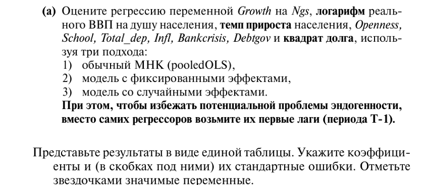

Сделаем преобразования, о которых нас просят

```python
data['log_realGDP'] = np.log(data['realGDP'])
data['pop_growth_rate'] = data.groupby('country')['pop'].pct_change()
data['debtgov_quad'] = np.power(data['debtgov'], 2)
```

```python
col_names_regr = [
    'ngs', 'log_realGDP', 'pop_growth_rate',
    'openness', 'school', 'total_dep',
    'infl', 'bankcrisis', 'debtgov', 'debtgov_quad'
]
```

Добавим лаги независимых переменных

```python
for col_name in col_names_regr:
    lag_col_name = 'lag_' + col_name
    data[lag_col_name] = data.groupby('country')[col_name].shift(1)
```

Исключим появившиеся пропуски

```python
data = data.dropna()
```

Первые лаги столбцов независимых переменных

```python
col_names_regr = ['lag_' + col_name for col_name in col_names_regr]
```

Модели

```python
models = {
    'PooledOLS': PooledOLS.from_formula,
    'FixedEffects': PanelOLS.from_formula,
    'RandomEffects': RandomEffects.from_formula
}
```

Формулы для моделей

```python
formulas = {
    'PooledOLS': 'growth ~ 1 + ' + ' + '.join(col_names_regr),
    'FixedEffects': 'growth ~ 1 + ' + ' + '.join(col_names_regr) + ' + EntityEffects',
    'RandomEffects': 'growth ~ 1 + ' + ' + '.join(col_names_regr)
}
```

Словарь результатов

```python
models_result = {
    'PooledOLS': None,
    'FixedEffects': None,
    'RandomEffects': None
}
```

Произведем обучение моделей

```python
for model in models:
    model_fit = models[model](formula=formulas[model],data=data).fit()
    models_result[model] = model_fit
```

Выведем результаты обучения

```python
for model in models_result:
    print(f'Модель: {model}')
    print(f'Формула: {formulas[model]}', end='\n'*2)
    display(models_result[model].summary)
    print(end='\n'*7)
```

```
Модель: PooledOLS
Формула: growth ~ 1 + lag_ngs + lag_log_realGDP + lag_pop_growth_rate + lag_openness + lag_school + lag_total_dep + lag_infl + lag_bankcrisis + lag_debtgov + lag_debtgov_quad
```

PooledOLS Estimation Summary

| Dep. Variable: | growth | R-squared: | 0.2557 |
| --- | --- | --- | --- |
| Estimator: | PooledOLS | R-squared (Between): | -2.9709 |
| No. Observations: | 504 | R-squared (Within): | 0.3131 |
| Date: | Thu, Jun 05 2025 | R-squared (Overall): | 0.2557 |
| Time: | 10:37:27 | Log-likelihood | -1052.2 |
| Cov. Estimator: | Unadjusted |  |  |
|  |  | F-statistic: | 16.939 |
| Entities: | 18 | P-value | 0.0000 |
| Avg Obs: | 28.000 | Distribution: | F(10,493) |
| Min Obs: | 28.000 |  |  |
| Max Obs: | 28.000 | F-statistic (robust): | 16.939 |
|  |  | P-value | 0.0000 |
| Time periods: | 28 | Distribution: | F(10,493) |
| Avg Obs: | 18.000 |  |  |
| Min Obs: | 18.000 |  |  |
| Max Obs: | 18.000 |  |  |

Parameter Estimates

|  | Parameter | Std. Err. | T-stat | P-value | Lower CI | Upper CI |
| --- | --- | --- | --- | --- | --- | --- |
| Intercept | 49.851 | 6.1622 | 8.0899 | 0.0000 | 37.744 | 61.959 |
| lag_ngs | 0.0622 | 0.0208 | 2.9967 | 0.0029 | 0.0214 | 0.1031 |
| lag_log_realGDP | -5.5177 | 0.6439 | -8.5697 | 0.0000 | -6.7827 | -4.2526 |
| lag_pop_growth_rate | -29.195 | 25.054 | -1.1653 | 0.2445 | -78.422 | 20.032 |
| lag_openness | -0.0078 | 0.0035 | -2.2412 | 0.0255 | -0.0146 | -0.0010 |
| lag_school | 0.3509 | 0.0767 | 4.5738 | 0.0000 | 0.2001 | 0.5016 |
| lag_total_dep | 0.0771 | 0.0310 | 2.4897 | 0.0131 | 0.0163 | 0.1379 |
| lag_infl | -0.2247 | 0.0298 | -7.5474 | 0.0000 | -0.2831 | -0.1662 |
| lag_bankcrisis | -1.8412 | 0.2515 | -7.3213 | 0.0000 | -2.3353 | -1.3471 |
| lag_debtgov | 4.6547 | 1.3600 | 3.4226 | 0.0007 | 1.9826 | 7.3267 |
| lag_debtgov_quad | -2.7047 | 0.7075 | -3.8228 | 0.0001 | -4.0949 | -1.3146 |

```
Модель: FixedEffects
Формула: growth ~ 1 + lag_ngs + lag_log_realGDP + lag_pop_growth_rate + lag_openness + lag_school + lag_total_dep + lag_infl + lag_bankcrisis + lag_debtgov + lag_debtgov_quad + EntityEffects
```

PanelOLS Estimation Summary

| Dep. Variable: | growth | R-squared: | 0.3647 |
| --- | --- | --- | --- |
| Estimator: | PanelOLS | R-squared (Between): | -35.786 |
| No. Observations: | 504 | R-squared (Within): | 0.3647 |
| Date: | Thu, Jun 05 2025 | R-squared (Overall): | -0.2668 |
| Time: | 10:37:27 | Log-likelihood | -1007.8 |
| Cov. Estimator: | Unadjusted |  |  |
|  |  | F-statistic: | 27.328 |
| Entities: | 18 | P-value | 0.0000 |
| Avg Obs: | 28.000 | Distribution: | F(10,476) |
| Min Obs: | 28.000 |  |  |
| Max Obs: | 28.000 | F-statistic (robust): | 27.328 |
|  |  | P-value | 0.0000 |
| Time periods: | 28 | Distribution: | F(10,476) |
| Avg Obs: | 18.000 |  |  |
| Min Obs: | 18.000 |  |  |
| Max Obs: | 18.000 |  |  |

Parameter Estimates

|  | Parameter | Std. Err. | T-stat | P-value | Lower CI | Upper CI |
| --- | --- | --- | --- | --- | --- | --- |
| Intercept | 78.286 | 10.176 | 7.6934 | 0.0000 | 58.292 | 98.281 |
| lag_ngs | 0.1037 | 0.0325 | 3.1880 | 0.0015 | 0.0398 | 0.1676 |
| lag_log_realGDP | -7.5749 | 1.0140 | -7.4701 | 0.0000 | -9.5674 | -5.5823 |
| lag_pop_growth_rate | -92.478 | 34.258 | -2.6995 | 0.0072 | -159.79 | -25.163 |
| lag_openness | 0.0093 | 0.0132 | 0.7046 | 0.4814 | -0.0166 | 0.0352 |
| lag_school | -0.2159 | 0.2307 | -0.9358 | 0.3499 | -0.6691 | 0.2374 |
| lag_total_dep | -0.0065 | 0.0550 | -0.1182 | 0.9060 | -0.1146 | 0.1016 |
| lag_infl | -0.3204 | 0.0382 | -8.3872 | 0.0000 | -0.3955 | -0.2454 |
| lag_bankcrisis | -1.9146 | 0.2471 | -7.7487 | 0.0000 | -2.4001 | -1.4291 |
| lag_debtgov | 5.1661 | 1.6418 | 3.1465 | 0.0018 | 1.9399 | 8.3922 |
| lag_debtgov_quad | -2.5348 | 0.8047 | -3.1502 | 0.0017 | -4.1159 | -0.9537 |

F-test for Poolability: 5.3872  
P-value: 0.0000  
Distribution: F(17,476)  
Included effects: Entity

```
Модель: RandomEffects
Формула: growth ~ 1 + lag_ngs + lag_log_realGDP + lag_pop_growth_rate + lag_openness + lag_school + lag_total_dep + lag_infl + lag_bankcrisis + lag_debtgov + lag_debtgov_quad
```

RandomEffects Estimation Summary

| Dep. Variable: | growth | R-squared: | 0.2557 |
| --- | --- | --- | --- |
| Estimator: | RandomEffects | R-squared (Between): | -2.9709 |
| No. Observations: | 504 | R-squared (Within): | 0.3131 |
| Date: | Thu, Jun 05 2025 | R-squared (Overall): | 0.2557 |
| Time: | 10:37:27 | Log-likelihood | -1052.2 |
| Cov. Estimator: | Unadjusted |  |  |
|  |  | F-statistic: | 16.939 |
| Entities: | 18 | P-value | 0.0000 |
| Avg Obs: | 28.000 | Distribution: | F(10,493) |
| Min Obs: | 28.000 |  |  |
| Max Obs: | 28.000 | F-statistic (robust): | 16.939 |
|  |  | P-value | 0.0000 |
| Time periods: | 28 | Distribution: | F(10,493) |
| Avg Obs: | 18.000 |  |  |
| Min Obs: | 18.000 |  |  |
| Max Obs: | 18.000 |  |  |

Parameter Estimates

|  | Parameter | Std. Err. | T-stat | P-value | Lower CI | Upper CI |
| --- | --- | --- | --- | --- | --- | --- |
| Intercept | 49.851 | 6.1622 | 8.0899 | 0.0000 | 37.744 | 61.959 |
| lag_ngs | 0.0622 | 0.0208 | 2.9967 | 0.0029 | 0.0214 | 0.1031 |
| lag_log_realGDP | -5.5177 | 0.6439 | -8.5697 | 0.0000 | -6.7827 | -4.2526 |
| lag_pop_growth_rate | -29.195 | 25.054 | -1.1653 | 0.2445 | -78.422 | 20.032 |
| lag_openness | -0.0078 | 0.0035 | -2.2412 | 0.0255 | -0.0146 | -0.0010 |
| lag_school | 0.3509 | 0.0767 | 4.5738 | 0.0000 | 0.2001 | 0.5016 |
| lag_total_dep | 0.0771 | 0.0310 | 2.4897 | 0.0131 | 0.0163 | 0.1379 |
| lag_infl | -0.2247 | 0.0298 | -7.5474 | 0.0000 | -0.2831 | -0.1662 |
| lag_bankcrisis | -1.8412 | 0.2515 | -7.3213 | 0.0000 | -2.3353 | -1.3471 |
| lag_debtgov | 4.6547 | 1.3600 | 3.4226 | 0.0007 | 1.9826 | 7.3267 |
| lag_debtgov_quad | -2.7047 | 0.7075 | -3.8228 | 0.0001 | -4.0949 | -1.3146 |

Напишем функцию для форматирования данных в таблице

```python
def format_val(val, std, pval, alpha=0.05, rounder=3):
    # Format value and standard deviation as strings with 4 decimal places
    val_str = np.round(val, rounder).astype(str)
    std_str = np.round(std, rounder).astype(str)

    # Combine into "value (std)" format
    base = np.char.add(np.char.add(np.char.add(val_str, ' ('), std_str), ')')

    # Append '*' if p-value is below significance level
    condition = pval < alpha
    result = np.where(condition, np.char.add(base, '*'), base)

    return result
```

Параметры моделей

```python
params = ['Intercept'] + col_names_regr
```

```python
# результаты моделей, * - значимый коэффициент
df_params = pd.DataFrame({model: format_val(models_result[model].params.values,models_result[model].std_errors.values,models_result[model].pvalues.values) for model in models_result},).set_index(pd.Index(params))
df_params
```

|  | PooledOLS | FixedEffects | RandomEffects |
| --- | --- | --- | --- |
| Intercept | 49.851 (6.162)* | 78.286 (10.176)* | 49.851 (6.162)* |
| lag_ngs | 0.062 (0.021)* | 0.104 (0.033)* | 0.062 (0.021)* |
| lag_log_realGDP | -5.518 (0.644)* | -7.575 (1.014)* | -5.518 (0.644)* |
| lag_pop_growth_rate | -29.195 (25.054) | -92.478 (34.258)* | -29.195 (25.054) |
| lag_openness | -0.008 (0.003)* | 0.009 (0.013) | -0.008 (0.003)* |
| lag_school | 0.351 (0.077)* | -0.216 (0.231) | 0.351 (0.077)* |
| lag_total_dep | 0.077 (0.031)* | -0.006 (0.055) | 0.077 (0.031)* |
| lag_infl | -0.225 (0.03)* | -0.32 (0.038)* | -0.225 (0.03)* |
| lag_bankcrisis | -1.841 (0.251)* | -1.915 (0.247)* | -1.841 (0.251)* |
| lag_debtgov | 4.655 (1.36)* | 5.166 (1.642)* | 4.655 (1.36)* |
| lag_debtgov_quad | -2.705 (0.708)* | -2.535 (0.805)* | -2.705 (0.708)* |

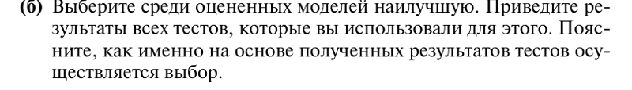

Пройдем по всем парам моделей

## PooledOLS и FixedEffects

```python
models_result['FixedEffects'].f_pooled
```

```
Pooled F-statistic
H0: Effects are zero
Statistic: 5.3872
P-value: 0.0000
Distributed: F(17,476)
WaldTestStatistic, id: 0x24e038cec10
```

## FixedEffects и RandomEffects

```python
def hausman_test(fe_model, re_model):
    """
    Проводит тест Хаусмана для сравнения фиксированных (FE) и случайных (RE) эффектов.

    Аргументы:
    - fe_model: модель с фиксированными эффектами (объект с атрибутами params и cov).
    - re_model: модель со случайными эффектами (объект с атрибутами params и cov).

    Возвращает:
    - stat: значение статистики теста.
    - p_value: p-значение для статистики.
    - df: степени свободы.
    - conclusion: вывод на основе p-значения (на русском языке).
    """
    # 1. Извлечение общих коэффициентов
    common_coef = fe_model.params.index.intersection(re_model.params.index)
    b_fe = fe_model.params.loc[common_coef].values
    b_re = re_model.params.loc[common_coef].values

    # 2. Ковариационные матрицы для общих коэффициентов
    V_fe = fe_model.cov.loc[common_coef, common_coef].values
    V_re = re_model.cov.loc[common_coef, common_coef].values

    # 3. Разность коэффициентов и ковариационных матриц
    coeff_diff = b_fe - b_re
    cov_diff = V_fe - V_re

    # 4. Обращение матрицы разности ковариаций
    try:
        inv_cov_diff = np.linalg.inv(cov_diff)
    except np.linalg.LinAlgError:
        inv_cov_diff = np.linalg.pinv(cov_diff)  # Используем псевдообратную матрицу при сингулярности

    # 5. Вычисление статистики теста
    stat = coeff_diff.T @ inv_cov_diff @ coeff_diff
    df = len(coeff_diff)
    p_value = 1 - chi2.cdf(stat, df)

    # 6. Вывод на основе p-значения
    conclusion = "Выбирайте Fixed Effects (p-value < 0.05)" if p_value < 0.05 else "Выбирайте Random Effects (p-value >= 0.05)"

    return stat, p_value, df, conclusion
```

```python
hausman_results = hausman_test(models_result['FixedEffects'],models_result['RandomEffects'])

print(f'''Статтистика: {hausman_results[0]}
p-value: {hausman_results[1]}
Степени свободы: {hausman_results[2]}
f'Заключение: {hausman_results[3]}''')
```

```
Статтистика: -169.25349071586226
p-value: 1.0
Степени свободы: 11
f'Заключение: Выбирайте Random Effects (p-value >= 0.05)
```

## PooledOLS и RandomEffects

```python
def breusch_pagan_test(pooled_model, re_model):
    """
    Проводит тест Бреуша-Пагана для сравнения моделей Pooled OLS и Random Effects (RE).

    Аргументы:
    - pooled_model: модель Pooled OLS (объект с атрибутом resids).
    - re_model: модель Random Effects (объект с атрибутом resids).

    Возвращает:
    - bp_stat: значение статистики теста.
    - p_value: p-значение для статистики (односторонний тест).
    - df: степени свободы (фиксированы как 1).
    - conclusion: вывод на основе p-значения (на русском языке).
    """
    # Проверка совпадения длин остатков (модели должны быть оценены на одинаковых данных)
    if len(pooled_model.resids) != len(re_model.resids):
        raise ValueError("Модели оценивались на разных данных")

    # Извлечение остатков из моделей
    pooled_residuals = pooled_model.resids
    re_residuals = re_model.resids

    # Вычисление суммы квадратов остатков для обеих моделей
    sum_squared_pooled = np.sum(pooled_residuals**2)
    sum_squared_re = np.sum(re_residuals**2)

    # Расчет логарифма отношения дисперсий (аналог теста на гетероскедастичность)
    log_ratio = np.log(sum_squared_pooled / sum_squared_re)

    # Расчет статистики теста Бреуша-Пагана
    n = len(pooled_residuals)
    bp_stat = (n * log_ratio) / 2

    # Вычисление p-значения (χ²-распределение с 1 степенью свободы)
    p_value = 1 - chi2.cdf(bp_stat, df=1)

    # Интерпретация результата на основе порога 0.05
    conclusion = ("Выбирайте Random Effects (p-value < 0.05)" if p_value < 0.05
                  else "Выбирайте Pooled OLS (p-value >= 0.05)")

    return bp_stat, p_value, 1, conclusion
```

```python
breusch_pagan_results = breusch_pagan_test(models_result['PooledOLS'],models_result['RandomEffects'])

print(f'''Статтистика: {breusch_pagan_results[0]}
p-value: {breusch_pagan_results[1]}
Степени свободы: {breusch_pagan_results[2]}
Заключение: {breusch_pagan_results[3]}''')
```

```
Статтистика: 0.0
p-value: 1.0
Степени свободы: 1
Заключение: Выбирайте Pooled OLS (p-value >= 0.05)
```

**Тесты показывают несогласованные результаты:**

- **F-тест $\Rightarrow$ Fixed Effects** (проверяет значимость фиксированных эффектов через сравнение моделей с и без них)
- **Hausman’а тест $\Rightarrow$ Random Effects** (сравнивает оценки FE и RE, отвергая случайные эффекты при значимых различиях)
- **Breusch-Pagan тест $\Rightarrow$ Pooled OLS** (предпочитает модель без учета индивидуальных эффектов)

**Учитывая строгость F-теста в оценке необходимости фиксированных эффектов и приоритетность его вывода, остановимся на модели Fixed Effects. Для уточнения выбора также сравним модели по критериям AIC и BIC.**

```python
# Вычисление информационных критериев AIC и BIC для сравнения моделей
def get_aic_bic(model):
    """
    Рассчитывает критерии Акаике (AIC) и Байесовский (BIC) для заданной модели.

    Формулы:
    AIC = -2 * log-likelihood + 2 * k
    BIC = -2 * log-likelihood + log(n) * k
    где k - число параметров, n - число наблюдений [[6]]

    Аргументы:
    - model: обученная модель с атрибутами params (параметры), resids (остатки), s2 (дисперсия)

    Возвращает:
    - aic: значение информационного критерия Акаике
    - bic: значение байесовского информационного критерия
    """
    # Количество параметров модели
    k = model.params.shape[0]

    # Количество наблюдений
    n = model.resids.shape[0]

    # Аппроксимация логарифма правдоподобия для нормального распределения
    llf = -n / 2 * (1 + np.log(2 * np.pi) + np.log(model.s2))

    # Расчёт AIC и BIC по классическим формулам
    aic = -2 * llf + 2 * k         # Критерий Акаике [[5]]
    bic = -2 * llf + np.log(n) * k # Байесовский критерий [[3]]

    return aic, bic

# Сравнение моделей по информационным критериям
for model_name in models_result:
    aic, bic = get_aic_bic(models_result[model_name])
    print(f"{model_name} | AIC: {aic:.4f} | BIC: {bic:.4f}")
```

```
PooledOLS | AIC: 2137.4226 | BIC: 2183.8710
FixedEffects | AIC: 2066.4211 | BIC: 2112.8694
RandomEffects | AIC: 2137.4226 | BIC: 2183.8710
```

**FixedEffects показал самые маленькие AIC и BIC $$\Downarrow$$ нашей моделью будет FixedEffects**

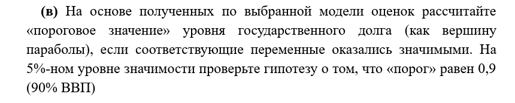

```python
model = models_result['FixedEffects']
b1 = model.params['lag_debtgov']
b2 = model.params['lag_debtgov_quad']
```

Порогом будет экстремум параболы

```python
threshold = -b1 / (2 * b2)
print(f"Пороговое значение долга: {threshold:.4f}")
```

```
Пороговое значение долга: 1.0190
```

Расчёт стандартной ошибки для оценки порогового значения

```python
cov_matrix = model.cov
```

Дисперсии оценок коэффициентов

```python
var_b1 = cov_matrix.loc['lag_debtgov', 'lag_debtgov']
var_b2 = cov_matrix.loc['lag_debtgov_quad', 'lag_debtgov_quad']
```

Ковариация между коэффициентами

```python
cov_b1_b2 = cov_matrix.loc['lag_debtgov', 'lag_debtgov_quad']
```

Компоненты формулы дисперсии порога

```python
term1 = (1 / (2 * b2))**2 * var_b1
term2 = (b1 / (2 * b2**2))**2 * var_b2
term3 = 2 * (1 / (2 * b2)) * (b1 / (2 * b2**2)) * cov_b1_b2
```

Стандартная ошибка порога

```python
se_threshold = np.sqrt(term1 + term2 - term3)
```

Проверка гипотезы H0: threshold = 0.9

```python
t_stat = (threshold - 0.9) / se_threshold
p_value = 2 * (1 - t.cdf(abs(t_stat), df=model.df_resid))

print(f"t = {t_stat:.3f}, p-value = {p_value:.3f}")
```

[output not shown]

Не можем отвергнуть H0

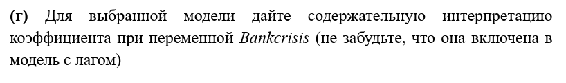

```python
model.params['lag_bankcrisis']
```

```
np.float64(-1.9145642367844455)
```

**Коэффициент при переменной `lag_bankcrisis` статистически значим и имеет отрицательное значение. Наличие банковского кризиса в предыдущем году приводит к снижению темпа прироста реального ВВП на душу населения (`growth`) на 1.91 %. Это свидетельствует о наличии запаздывающего негативного влияния кризиса на экономическое развитие .**